# Mortalidad por cáncer de pulmón en Ohio (décadas de 1960 a 1980)

## 3. Exploración de Promedios Móviles Espaciales

La matriz $W$ actúa como un **operador de rezago espacial**. Al calcular el promedio ponderado de los vecinos, suavizamos la variable para detectar tendencias regionales de largo alcance en lugar de ruido local.

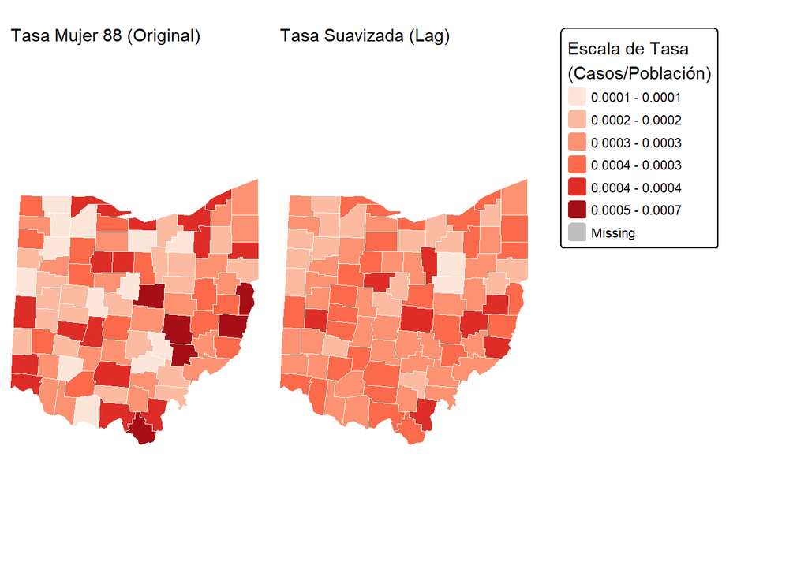

La comparación bajo una escala unificada demuestra que, al eliminar el ruido estadístico local mediante el rezago espacial (Lag), persiste una estructura regional de alta incidencia de cáncer de pulmón en mujeres en el sudeste de Ohio.

## 4. Análisis de Eigenvectores (MESF/MEM)

La técnica **MESF** filtra la autocorrelación de los residuales y la transfiere al intercepto del modelo. Los eigenvectores representan patrones de mapas: los de valores propios altos muestran gradientes globales, mientras que los bajos muestran contrastes locales.

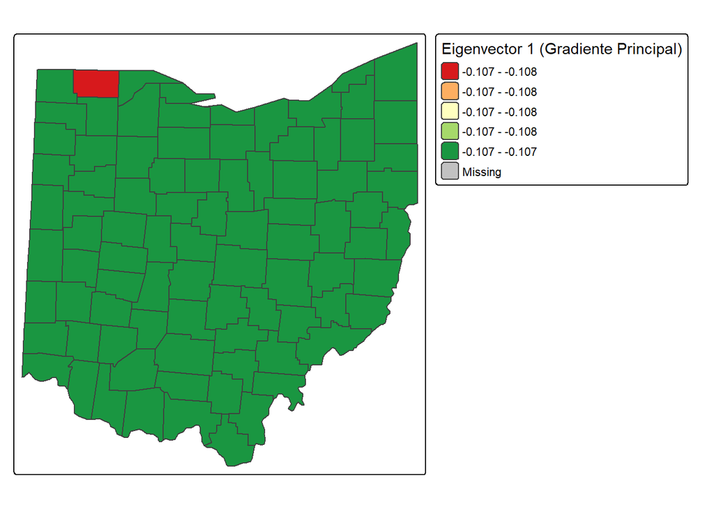

Cuando utilizas una matriz de conectividad basada en Atributos (nb_atributo) donde casi todos los condados están conectados entre sí con pesos muy similares, la eigendecomposición “colapsa”. En lugar de un gradiente suave (que es lo que buscamos), obtienes un eigenvector que solo resalta un valor atípico (outlier) y deja al resto como una masa uniforme. Esto no sirve para modelar la estructura espacial. (en este caso con esta W no sirve hacer MESF/MEM)

## 5. Pruebas de Diagnóstico para Selección del Modelo (LM Tests)

Para decidir si la dependencia espacial debe modelarse en la **variable dependiente** (Modelo de Rezago/Lag) o en los **términos de error** (Modelo de Error), utilizamos los Tests del Multiplicador de Lagrange sobre un modelo base de Mínimos Cuadrados.

```
## [1] 0
```

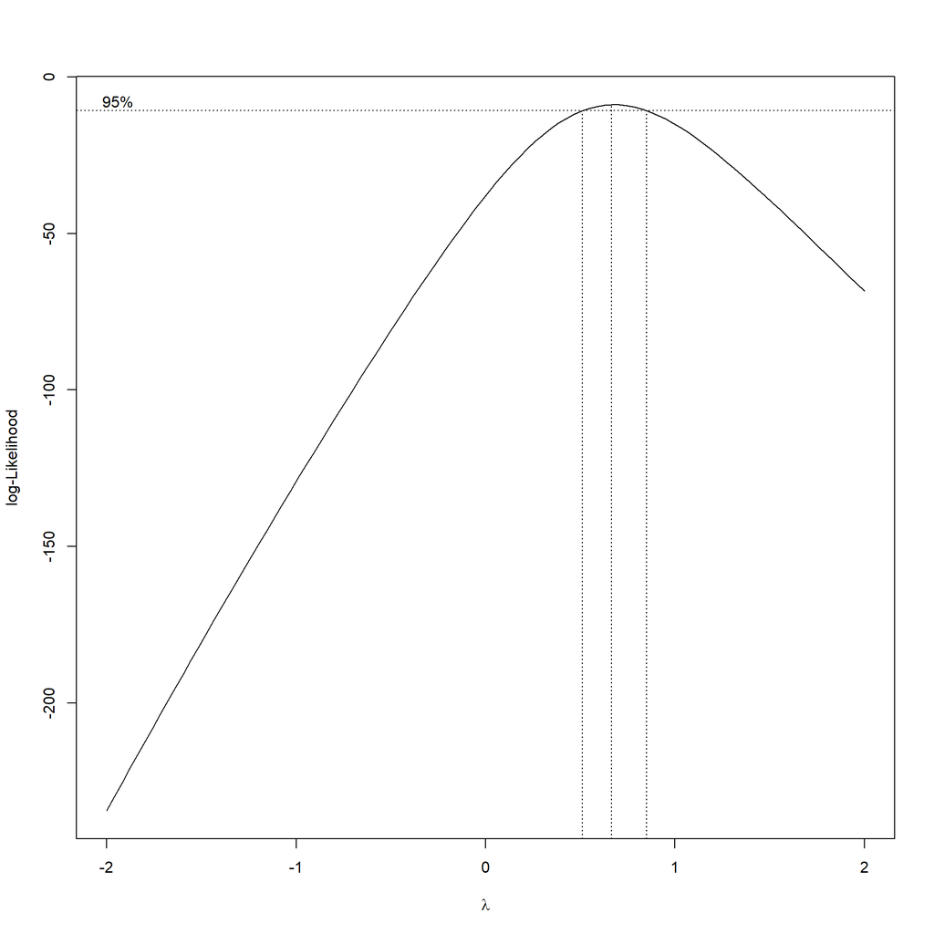

```
## [1] 0.6666667
```

```
##
## Call:
## lm(formula = tasa_mujer_88^lambda ~ tasa_68 + tasa_hombre_68 +
##     tasa_mujer_68 + cambio_78_88 + tasa_white_78 + tasa_hombre_78 +
##     pop_total78 + tasa_mujer_78 + tasa_white_88 + tasa_hombre_88 +
##     casos_totales88, data = ohlung)
##
## Residuals:
##        Min         1Q     Median         3Q        Max
## -4.350e-04 -7.401e-05  2.501e-05  7.600e-05  2.392e-04
##
## Coefficients:
##                   Estimate Std. Error t value Pr(>|t|)
## (Intercept)      1.288e-03  9.721e-05  13.244  < 2e-16 ***
## tasa_68          8.846e+00  4.941e+00   1.790  0.07736 .
## tasa_hombre_68  -4.333e+00  2.417e+00  -1.793  0.07703 .
## tasa_mujer_68   -4.471e+00  2.480e+00  -1.803  0.07541 .
## cambio_78_88     1.647e+01  7.134e-01  23.079  < 2e-16 ***
## tasa_white_78    1.949e+00  1.120e+00   1.740  0.08595 .
## tasa_hombre_78   7.131e+00  6.754e-01  10.559  < 2e-16 ***
## pop_total78      3.084e-09  1.326e-09   2.326  0.02269 *
## tasa_mujer_78    7.183e+00  7.263e-01   9.889 2.69e-15 ***
## tasa_white_88    2.790e+00  7.022e-01   3.972  0.00016 ***
## tasa_hombre_88  -9.235e+00  1.515e-01 -60.960  < 2e-16 ***
## casos_totales88 -4.690e-06  2.092e-06  -2.241  0.02792 *
## ---
## Signif. codes:  0 '***' 0.001 '**' 0.01 '*' 0.05 '.' 0.1 ' ' 1
##
## Residual standard error: 0.0001328 on 76 degrees of freedom
## Multiple R-squared:  0.991,  Adjusted R-squared:  0.9897
## F-statistic: 761.8 on 11 and 76 DF,  p-value: < 2.2e-16
```

```
##
##  Global Moran I for regression residuals
##
## data:
## model: lm(formula = tasa_mujer_88^lambda ~ tasa_68 + tasa_hombre_68 +
## tasa_mujer_68 + cambio_78_88 + tasa_white_78 + tasa_hombre_78 +
## pop_total78 + tasa_mujer_78 + tasa_white_88 + tasa_hombre_88 +
## casos_totales88, data = ohlung)
## weights: W_seleccionada
##
## Moran I statistic standard deviate = 0.90204, p-value = 0.367
## alternative hypothesis: two.sided
## sample estimates:
## Observed Moran I      Expectation         Variance
##      0.027887042     -0.021942783      0.003051568
```

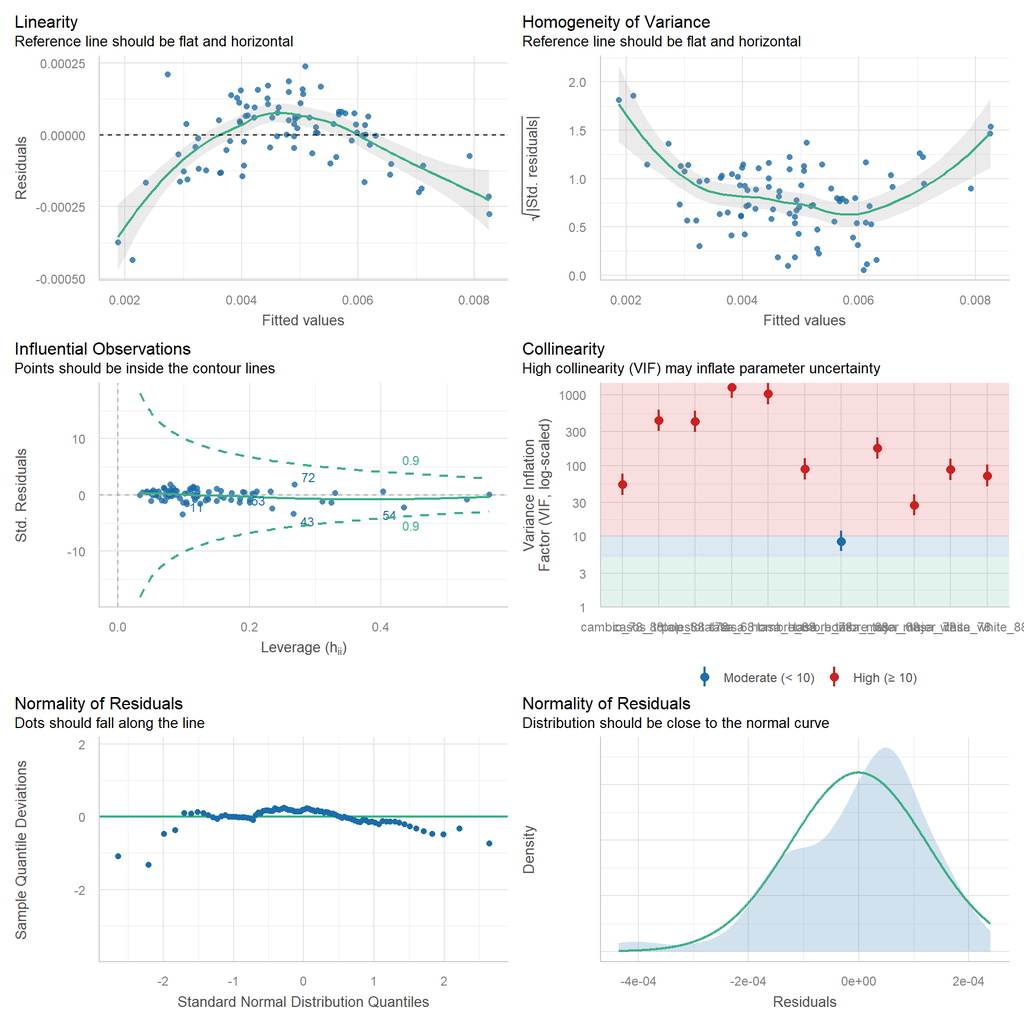

```
##
## Call:
## lm(formula = tasa_mujer_88^0.9 ~ tasa_hombre_78 + tasa_hombre_88 +
##     tasa_white_88, data = ohlung)
##
## Residuals:
##        Min         1Q     Median         3Q        Max
## -1.786e-04 -4.570e-05 -4.400e-06  2.656e-05  4.793e-04
##
## Coefficients:
##                  Estimate Std. Error t value Pr(>|t|)
## (Intercept)     3.489e-05  3.384e-05   1.031   0.3055
## tasa_hombre_78  9.741e-02  4.726e-02   2.061   0.0424 *
## tasa_hombre_88 -1.774e+00  8.383e-02 -21.165   <2e-16 ***
## tasa_white_88   3.667e+00  1.353e-01  27.106   <2e-16 ***
## ---
## Signif. codes:  0 '***' 0.001 '**' 0.01 '*' 0.05 '.' 0.1 ' ' 1
##
## Residual standard error: 7.899e-05 on 84 degrees of freedom
## Multiple R-squared:  0.9181, Adjusted R-squared:  0.9151
## F-statistic: 313.8 on 3 and 84 DF,  p-value: < 2.2e-16
```

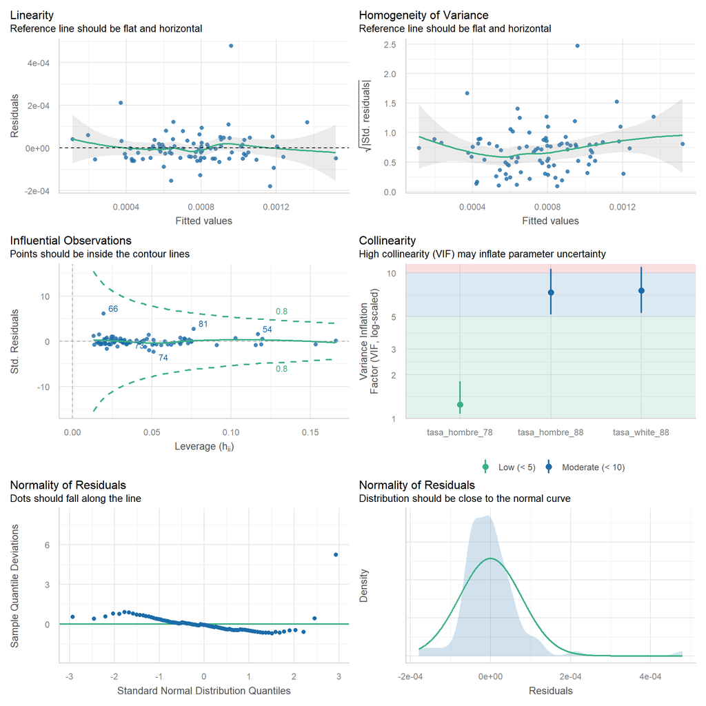

```
##
##  Global Moran I for regression residuals
##
## data:
## model: lm(formula = tasa_mujer_88^0.9 ~ tasa_hombre_78 + tasa_hombre_88
## + tasa_white_88, data = ohlung)
## weights: W_seleccionada
##
## Moran I statistic standard deviate = 0.71122, p-value = 0.4769
## alternative hypothesis: two.sided
## sample estimates:
## Observed Moran I      Expectation         Variance
##       0.01889075      -0.01989429       0.00297387
```

Se evalua el mejor modelo con pruebas mas robustas de Anselin (lm.RStests) que controlan por la posible presencia simultánea de ambos tipos de dependencia espacial (lag y error).

```
##
##  Rao's score (a.k.a Lagrange multiplier) diagnostics for spatial
##  dependence
##
## data:
## model: lm(formula = tasa_mujer_88^0.9 ~ tasa_hombre_78 + tasa_hombre_88
## + tasa_white_88, data = ohlung)
## test weights: W_seleccionada
##
## RSerr = 0.10756, df = 1, p-value = 0.7429
##
##
##  Rao's score (a.k.a Lagrange multiplier) diagnostics for spatial
##  dependence
##
## data:
## model: lm(formula = tasa_mujer_88^0.9 ~ tasa_hombre_78 + tasa_hombre_88
## + tasa_white_88, data = ohlung)
## test weights: W_seleccionada
##
## RSlag = 0.023649, df = 1, p-value = 0.8778
##
##
##  Rao's score (a.k.a Lagrange multiplier) diagnostics for spatial
##  dependence
##
## data:
## model: lm(formula = tasa_mujer_88^0.9 ~ tasa_hombre_78 + tasa_hombre_88
## + tasa_white_88, data = ohlung)
## test weights: W_seleccionada
##
## adjRSerr = 0.084249, df = 1, p-value = 0.7716
##
##
##  Rao's score (a.k.a Lagrange multiplier) diagnostics for spatial
##  dependence
##
## data:
## model: lm(formula = tasa_mujer_88^0.9 ~ tasa_hombre_78 + tasa_hombre_88
## + tasa_white_88, data = ohlung)
## test weights: W_seleccionada
##
## adjRSlag = 0.00034155, df = 1, p-value = 0.9853
##
##
##  Rao's score (a.k.a Lagrange multiplier) diagnostics for spatial
##  dependence
##
## data:
## model: lm(formula = tasa_mujer_88^0.9 ~ tasa_hombre_78 + tasa_hombre_88
## + tasa_white_88, data = ohlung)
## test weights: W_seleccionada
##
## SARMA = 0.1079, df = 2, p-value = 0.9475
```